# Chap5_8

J.H AHN

2021 12 8

## 5.8 Evaluating point forecast accuracy

### Training and test sets

잔차의 크기가 중요한 것이 아니라 예측이 얼마나 정확하게 되느냐가 중요한 평가기준이다.  
예측 정확도는 예측 모델을 이용해 새로운 데이터로 예측할 때 얼마나 잘 예측하는지로써 평가된다.

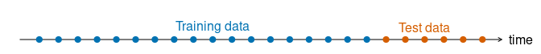

모델을 선택할 때 사용 가능한 데이터를 **Training set**과 **Test set**으로 나눠서 사용하는 것이 일반적이다.  
Training set은 예측 모델의 매개변수들을 추정하는데 사용하고 Test set은 Training set을 이용하여 만든 모델을 평가하는데 사용된다.  
Test set은 예측 모델을 만드는데는 사용되지 않기 때문에 새로운 데이터를 예측할 때 얼마나 잘 예측할 수 있는지에 대한 지표를 보여줄 수 있어야 한다.

Test set은 일반적으로 전체 데이터의 20%정도를 사용하지만 상황에 따라 다르게 배분할 수 있다.  
Training set과 Test set으로 나눠서 예측 모델을 만들 때는 아래 사항을 유의해야 한다.

- Training set에 잘 맞는(fit) 모델이 반드시 새로운 데이터에 대한 예측을 잘 하는 것은 아니다. (overfitting)
- 충분한 매개변수가 있는 모델을 사용하면 항상 완벽하게 적합(fit)시킬 수 있다.
- 모델이 데이터에 과도하게 fit되는 것은 데이터에서 Systematic pattern을 인식하지 못하는 것만큼 나쁜 것이다.

### Functions to subset a time series

예를 들어

```r
aus_production %>%
    filter(year(Quarter) >= 1995)
```

```
## # A tsibble: 62 x 7 [1Q]
##    Quarter  Beer Tobacco Bricks Cement Electricity   Gas
##      <qtr> <dbl>   <dbl>  <dbl>  <dbl>       <dbl> <dbl>
##  1 1995 Q1   426    4714    430   1626       41768   131
##  2 1995 Q2   408    3939    457   1703       43686   167
##  3 1995 Q3   416    6137    417   1733       46022   181
##  4 1995 Q4   520    4739    370   1545       42800   145
##  5 1996 Q1   409    4275    310   1526       43661   133
##  6 1996 Q2   398    5239    358   1593       44707   162
##  7 1996 Q3   398    6293    379   1706       46326   184
##  8 1996 Q4   507    5575    369   1699       43346   146
##  9 1997 Q1   432    4802    330   1511       43938   135
## 10 1997 Q2   398    5523    390   1785       45828   171
## # ... with 52 more rows
```

1995년 이후의 데이터를 추출한다.  
혹은 `tsibble::filter_index()` 함수를 사용해도 동일한 결과를 얻을 수 있다.

```r
aus_production %>%
    filter_index("1995 Q1" ~ .)
```

```
## # A tsibble: 62 x 7 [1Q]
##    Quarter  Beer Tobacco Bricks Cement Electricity   Gas
##      <qtr> <dbl>   <dbl>  <dbl>  <dbl>       <dbl> <dbl>
##  1 1995 Q1   426    4714    430   1626       41768   131
##  2 1995 Q2   408    3939    457   1703       43686   167
##  3 1995 Q3   416    6137    417   1733       46022   181
##  4 1995 Q4   520    4739    370   1545       42800   145
##  5 1996 Q1   409    4275    310   1526       43661   133
##  6 1996 Q2   398    5239    358   1593       44707   162
##  7 1996 Q3   398    6293    379   1706       46326   184
##  8 1996 Q4   507    5575    369   1699       43346   146
##  9 1997 Q1   432    4802    330   1511       43938   135
## 10 1997 Q2   398    5523    390   1785       45828   171
## # ... with 52 more rows
```

또 다른 유용한 함수로 `slice()`가 있는데 이것은 필요한 범위만큼 잘라내어 가져오게 해 준다.  
예를 들어 20개전 관측치 (1년 = 4분기이므로 현재부터 이전 5년치)를 추출하고 싶다면 아래와 같이 쓸 수 있다.

```r
aus_production %>%
    slice(n()-19:0)
```

```
## # A tsibble: 20 x 7 [1Q]
##    Quarter  Beer Tobacco Bricks Cement Electricity   Gas
##      <qtr> <dbl>   <dbl>  <dbl>  <dbl>       <dbl> <dbl>
##  1 2005 Q3   408      NA     NA   2340       56043   221
##  2 2005 Q4   482      NA     NA   2265       54992   180
##  3 2006 Q1   438      NA     NA   2027       57112   171
##  4 2006 Q2   386      NA     NA   2278       57157   224
##  5 2006 Q3   405      NA     NA   2427       58400   233
##  6 2006 Q4   491      NA     NA   2451       56249   192
##  7 2007 Q1   427      NA     NA   2140       56244   187
##  8 2007 Q2   383      NA     NA   2362       55036   234
##  9 2007 Q3   394      NA     NA   2536       59806   245
## 10 2007 Q4   473      NA     NA   2562       56411   205
## 11 2008 Q1   420      NA     NA   2183       59118   194
## 12 2008 Q2   390      NA     NA   2558       56660   229
## 13 2008 Q3   410      NA     NA   2612       64067   249
## 14 2008 Q4   488      NA     NA   2373       59045   203
## 15 2009 Q1   415      NA     NA   1963       58368   196
## 16 2009 Q2   398      NA     NA   2160       57471   238
## 17 2009 Q3   419      NA     NA   2325       58394   252
## 18 2009 Q4   488      NA     NA   2273       57336   210
## 19 2010 Q1   414      NA     NA   1904       58309   205
## 20 2010 Q2   374      NA     NA   2401       58041   236
```

`slice()`함수는 그룹별로도 사용할 수 있는데 그룹으로 묶은 다음 필요한 그룹의 부분만 추출할 수도 있음. 아래 예는 State, Industry 그룹별로 12개씩 데이터를 추출한 예임.

```r
aus_retail %>%
    group_by(State, Industry) %>%
    slice(1:12)
```

```
## # A tsibble: 1,824 x 5 [1M]
## # Key:       State, Industry [152]
## # Groups:    State, Industry [152]
##    State                        Industry            `Series ID`   Month Turnover
##    <chr>                        <chr>               <chr>         <mth>    <dbl>
##  1 Australian Capital Territory Cafes, restaurants~ A3349849A    1982 4      4.4
##  2 Australian Capital Territory Cafes, restaurants~ A3349849A    1982 5      3.4
##  3 Australian Capital Territory Cafes, restaurants~ A3349849A    1982 6      3.6
##  4 Australian Capital Territory Cafes, restaurants~ A3349849A    1982 7      4
##  5 Australian Capital Territory Cafes, restaurants~ A3349849A    1982 8      3.6
##  6 Australian Capital Territory Cafes, restaurants~ A3349849A    1982 9      4.2
##  7 Australian Capital Territory Cafes, restaurants~ A3349849A   1982 10      4.8
##  8 Australian Capital Territory Cafes, restaurants~ A3349849A   1982 11      5.4
##  9 Australian Capital Territory Cafes, restaurants~ A3349849A   1982 12      6.9
## 10 Australian Capital Territory Cafes, restaurants~ A3349849A    1983 1      3.8
## # ... with 1,814 more rows
```

### Forecast errors

예측 **오차(error)**는 관측값과 예측값 간의 차이이다.  
여기서 오차는 실수를 의미하는 것이 아닌 관찰에서 예측할 수 없는 것을 의미한다.

$$e_{T+h} = y_{T+h} - \hat{y}_{T+h|T}$$

$\{y_1,\dots,y_T\}$는 Training set에서 주어지는 것이고, $\{y_{T+1},y_{T+2},\dots\}$는 Test set에서 주어지는 값이다.

예측 오차는 두 가지 면에서 잔차(residuals)와 다르다.

1. residulas은 training set에서 계산되고, errors는 test set에서 계산된다.
2. residulas은 one-step forecast를 기반으로 하는 반면, errors는 multi-step forecast에 포함된다.

예측 오차는 다양한 방식으로 표시하여 예측 정확도를 측정할 수 있다.

### Scale-dependent errors

예측 오차는 데이터와 동일한 스케일을 가진다.  
따라서 $e_t$로만 측정된 Accuracy는 스케일에 따라 달라지며 다른 단위계를 포함하는 데이터를 비교하는데는 사용할 수 없다.

오차의 절대값 혹은 제곱값으로 나타내는 scale-dependent한 가장 일반적으로 사용되는 측정치는 아래와 같다.

$$\begin{align*}
\text{Mean absolute error: MAE} & = \text{mean}(|e_{t}|),\\
\text{Root mean squared error: RMSE} & = \sqrt{\text{mean}(e_{t}^2)}.
\end{align*}$$

단일 시계열 또는 동일한 단위계가 사용된 여러 시계열의 예측값을 비교할 때 MAE는 이해하기 쉽고, 계산이 용이하여 널리 사용된다.  
MAE를 최소화하는 예측방법은 중간값(median)예측으로 이어지는 반면 RMSE를 최소화하면 평균(mean)예측이 된다.  
RMSE가 해석하기는 어렵지만 더 널리 사용된다.

### Percentage errors

백분율 오차는 $p_{t} = 100 e_{t}/y_{t}$로 나타낼 수 있다.  
백분율 오차는 단위가 없는 이점이 있어 테이터 간 예측 성능을 비교하는데 자주 사용된다.  
가장 일반적으로 사용되는 MAPE는 아래와 같이 구할 수 있다.

$$\text{Mean absolute percentage error: MAPE} = \text{mean}(|p_{t}|)$$

MAPE는 $y_{t}=0$이 되거나 $y_t$가 0에 가까워지면 무한대에 가까운 값을 보여주는 단점이 있다.  
또 다른 문제로 측정단위에 의미있는 0이 있다고 가정하는 것이다.  
예를 들어 화씨나 섭씨 온도 예측의 정확도를 측정할 때 백분율 오차는 아무런 의미가 없다.  
온도에는 임의의 영점이 존재하는 것이 아니기 때문이다.

또한 MAPE는 positive errors 보다 negative errors에 더 큰 페널티를 부과한다는 단점이 있다. 이런 현상은 M3 forecasting competition에서 사용했던 Armstrong (1978, p. 348)이 제안한 소위 “대칭(symmetric)”MAPE(=sMAPE)라는 개념을 만들어냈다.

$$\text{sMAPE} = \text{mean}\left(200|y_{t} - \hat{y}_{t}|/(y_{t}+\hat{y}_{t})\right)$$

그러나 만약 $y_t$가 0에 가까워지면 $\hat y_t$도 0에 가까워지게 되므로 여전히 0에 가까운 숫자로 나눠야 하는 계산의 불안정이 생길 수 있다. 또한 sMAPE값이 음수가 나올 수도 있기 때문에 실제로는 “백분율 오차의 절대값”이 아니다.  
이 때문에 Hyndman & Koehler(2006)는 sMAPE를 사용하지 말 것을 권장하고 있다.

### Scaled errors

Hyndman & Koehler(2006)는 다른 단위를 사용하여 계열에 대한 예측 정확도를 비교할 때 백분율 오차를 사용하는 대안으로 척도 오차(scaled errors)를 제안했다.  
간단한 예측 방법에서 *training* MAE를 기반으로 하는 오차를 계산하는 방법이다.

비계절성 시계열의 경우 척도 오차를 정의하는 유용한 방법으로 naive forecast를 사용한다.

$$q_{j} = \frac{\displaystyle e_{j}}
{\displaystyle\frac{1}{T-1}\sum_{t=2}^T |y_{t}-y_{t-1}|}$$

분자와 분모는 모두 원래 데이터의 scale을 사용하기 때문에 $q_{j}$는 scale과 무관한다.  
만약 training set에서 계산된 average one-step naive forecast보다 예측이 더 좋으면 1보다 작은 값이 나타내고, 반대로 training set에서 계산된 average one-step naive forecast보다 예측이 더 나쁘면 1보다 더 큰 수를 나타낸다.

계절성이 있는 시계열에서, 척도 오차는 seasonal naive forecasts를 이용하여 아래와 같이 정의할 수 있다.

$$q_{j} = \frac{\displaystyle e_{j}}
{\displaystyle\frac{1}{T-m}\sum_{t=m+1}^T |y_{t}-y_{t-m}|}$$

*mean absolute scaled error*는 간단하게 아래와 같이 나타낼 수 있다.

$$\text{MASE} = \text{mean}(|q_{j}|)$$

비슷하게 *root mean squared scaled error*도 아래와 같이 나타낼 수 있다.

$$\text{RMSSE} = \sqrt{\text{mean}(q_{j}^2)}$$

$$q^2_{j} = \frac{\displaystyle e^2_{j}}
{\displaystyle\frac{1}{T-m}\sum_{t=m+1}^T (y_{t}-y_{t-m})^2}$$

여기서 $m=1$로 두면 계절성 없는 데이터(non-seasonal data)가 된다.

### Examples

```r
recent_production <- aus_production %>%
    filter(year(Quarter) >= 1992)

recent_production
```

```
## # A tsibble: 74 x 7 [1Q]
##    Quarter  Beer Tobacco Bricks Cement Electricity   Gas
##      <qtr> <dbl>   <dbl>  <dbl>  <dbl>       <dbl> <dbl>
##  1 1992 Q1   443    5777    383   1289       38332   117
##  2 1992 Q2   410    5853    404   1501       39774   151
##  3 1992 Q3   420    6416    446   1539       42246   175
##  4 1992 Q4   532    5825    420   1568       38498   129
##  5 1993 Q1   433    5724    394   1450       39460   116
##  6 1993 Q2   421    6036    462   1668       41356   149
##  7 1993 Q3   410    6570    475   1648       42949   163
##  8 1993 Q4   512    5675    443   1863       40974   138
##  9 1994 Q1   449    5311    421   1468       40162   127
## 10 1994 Q2   381    5717    475   1755       41199   159
## # ... with 64 more rows
```

```r
beer_train <- recent_production %>%
    filter(year(Quarter) <= 2007)

beer_train
```

```
## # A tsibble: 64 x 7 [1Q]
##    Quarter  Beer Tobacco Bricks Cement Electricity   Gas
##      <qtr> <dbl>   <dbl>  <dbl>  <dbl>       <dbl> <dbl>
##  1 1992 Q1   443    5777    383   1289       38332   117
##  2 1992 Q2   410    5853    404   1501       39774   151
##  3 1992 Q3   420    6416    446   1539       42246   175
##  4 1992 Q4   532    5825    420   1568       38498   129
##  5 1993 Q1   433    5724    394   1450       39460   116
##  6 1993 Q2   421    6036    462   1668       41356   149
##  7 1993 Q3   410    6570    475   1648       42949   163
##  8 1993 Q4   512    5675    443   1863       40974   138
##  9 1994 Q1   449    5311    421   1468       40162   127
## 10 1994 Q2   381    5717    475   1755       41199   159
## # ... with 54 more rows
```

```r
beer_fit <- beer_train %>%
    model(
        Mean = MEAN(Beer),
        `Naïve` = NAIVE(Beer),
        `Seasonal naïve` = SNAIVE(Beer),
        Drift = RW(Beer ~ drift())
    )

beer_fit
```

```
## # A mable: 1 x 4
##      Mean   Naive `Seasonal naive`         Drift
##   <model> <model>          <model>       <model>
## 1  <MEAN> <NAIVE>         <SNAIVE> <RW w/ drift>
```

```r
beer_fc <- beer_fit %>%
    forecast(h = 10)

beer_fc
```

```
## # A fable: 40 x 4 [1Q]
## # Key:     .model [4]
##    .model Quarter         Beer .mean
##    <chr>    <qtr>       <dist> <dbl>
##  1 Mean   2008 Q1 N(435, 1964)  435.
##  2 Mean   2008 Q2 N(435, 1964)  435.
##  3 Mean   2008 Q3 N(435, 1964)  435.
##  4 Mean   2008 Q4 N(435, 1964)  435.
##  5 Mean   2009 Q1 N(435, 1964)  435.
##  6 Mean   2009 Q2 N(435, 1964)  435.
##  7 Mean   2009 Q3 N(435, 1964)  435.
##  8 Mean   2009 Q4 N(435, 1964)  435.
##  9 Mean   2010 Q1 N(435, 1964)  435.
## 10 Mean   2010 Q2 N(435, 1964)  435.
## # ... with 30 more rows
```

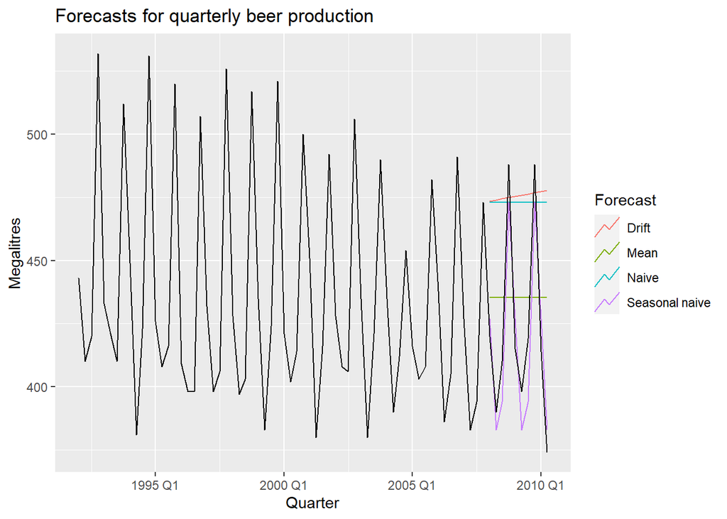

```r
beer_fc %>%
    autoplot(
        aus_production %>% filter(year(Quarter) >= 1992),
        level = NULL
    ) +
    labs(
        y = "Megalitres",
        title = "Forecasts for quarterly beer production"
    ) +
    guides(colour = guide_legend(title = "Forecast"))
```

위 plot은 2007년 말까지 데이터를 추출하여 분기별 호주 맥주 생산량을 네가지 예측 방법을 사용하여 예측한 결과를 보여준다.  
아래는 이 기간에 대한 예측 정확도를 계산한 결과이다.

```r
accuracy(beer_fc, recent_production)
```

```
## # A tibble: 4 x 10
##   .model         .type    ME  RMSE   MAE    MPE  MAPE  MASE RMSSE    ACF1
##   <chr>          <chr> <dbl> <dbl> <dbl>  <dbl> <dbl> <dbl> <dbl>   <dbl>
## 1 Drift          Test  -54.0  64.9  58.9 -13.6  14.6  4.12  3.87  -0.0741
## 2 Mean           Test  -13.8  38.4  34.8  -3.97  8.28 2.44  2.29  -0.0691
## 3 Naive          Test  -51.4  62.7  57.4 -13.0  14.2  4.01  3.74  -0.0691
## 4 Seasonal naive Test    5.2  14.3  13.4   1.15  3.17 0.937 0.853  0.132
```

`accuracy()` 함수는 다양한 정확도 측정값을 계산할 때 사용한다.  
위 예시에서 beer_fc는 예측모델, recent_production은 예측 기간이 포함된 데이터를 의미한다.

plot을 보면 seasonal naive method가 가장 적합해 보이지만 여전히 더 개선할 수 있는 방법이 있다.  
때로는 어떤 정확도 측정값으로 평가하느냐에 따라 다른 결론에 이를 수 있다.  
그러나 이 경우에는 모든 측정값이 Seasonal naive method가 가장 좋은 것으로 평가하고 있다.

계절성이 없는 구글의 주가를 예측한 예시를 보자.  
아래 예시는 2015년 종가와 세가지 기법으로 예측한 2016년 1월 주가를 보여준다.

```r
# Re-index based on trading days
google_stock <-
    gafa_stock %>%
    filter(Symbol == "GOOG", year(Date) >= 2015) %>%
    mutate(day = row_number()) %>%
    update_tsibble(index = day, regular = TRUE)

# Filter the year of interest
google_2015 <-
    google_stock %>%
    filter(year(Date) == 2015)

google_2015
```

```
## # A tsibble: 252 x 9 [1]
## # Key:       Symbol [1]
##    Symbol Date        Open  High   Low Close Adj_Close  Volume   day
##    <chr>  <date>     <dbl> <dbl> <dbl> <dbl>     <dbl>   <dbl> <int>
##  1 GOOG   2015-01-02  526.  528.  521.  522.      522. 1447600     1
##  2 GOOG   2015-01-05  520.  521.  510.  511.      511. 2059800     2
##  3 GOOG   2015-01-06  512.  513.  498.  499.      499. 2899900     3
##  4 GOOG   2015-01-07  504.  504.  497.  498.      498. 2065100     4
##  5 GOOG   2015-01-08  495.  501.  488.  500.      500. 3353600     5
##  6 GOOG   2015-01-09  502.  502.  492.  493.      493. 2069400     6
##  7 GOOG   2015-01-12  492.  493.  485.  490.      490. 2322400     7
##  8 GOOG   2015-01-13  496.  500.  490.  493.      493. 2370500     8
##  9 GOOG   2015-01-14  492.  500.  490.  498.      498. 2235700     9
## 10 GOOG   2015-01-15  503.  503.  495.  499.      499. 2715800    10
## # ... with 242 more rows
```

```r
google_jan_2016 <-
    google_stock %>%
    filter(yearmonth(Date) == yearmonth("2016 Jan"))

google_jan_2016
```

```
## # A tsibble: 19 x 9 [1]
## # Key:       Symbol [1]
##    Symbol Date        Open  High   Low Close Adj_Close  Volume   day
##    <chr>  <date>     <dbl> <dbl> <dbl> <dbl>     <dbl>   <dbl> <int>
##  1 GOOG   2016-01-04  743   744.  731.  742.      742. 3272800   253
##  2 GOOG   2016-01-05  746.  752   739.  743.      743. 1950700   254
##  3 GOOG   2016-01-06  730   747.  729.  744.      744. 1947000   255
##  4 GOOG   2016-01-07  730.  738.  719.  726.      726. 2963700   256
##  5 GOOG   2016-01-08  731.  733.  713   714.      714. 2450900   257
##  6 GOOG   2016-01-11  717.  719.  704.  716.      716. 2089300   258
##  7 GOOG   2016-01-12  722.  729.  717.  726.      726. 2024500   259
##  8 GOOG   2016-01-13  731.  735.  699.  701.      701. 2501700   260
##  9 GOOG   2016-01-14  705.  722.  689.  715.      715. 2225800   261
## 10 GOOG   2016-01-15  692.  707.  685.  694.      694. 3608100   262
## 11 GOOG   2016-01-19  703.  710.  693.  702.      702. 2268100   263
## 12 GOOG   2016-01-20  689.  707.  673.  698.      698. 3445000   264
## 13 GOOG   2016-01-21  702.  719.  694.  707.      707. 2412200   265
## 14 GOOG   2016-01-22  724.  728.  720.  725.      725. 2011800   266
## 15 GOOG   2016-01-25  724.  730.  710.  712.      712. 1711700   267
## 16 GOOG   2016-01-26  714.  718.  706.  713.      713. 1324300   268
## 17 GOOG   2016-01-27  714.  718.  694.  700.      700. 2194200   269
## 18 GOOG   2016-01-28  722.  734.  712.  731.      731. 2676400   270
## 19 GOOG   2016-01-29  732.  745.  727.  743.      743. 3474300   271
```

```r
google_fit <- google_2015 %>%
    model(
        Mean = MEAN(Close),
        `Naïve` = NAIVE(Close),
        Drift = RW(Close ~ drift())
    )

google_fit
```

```
## # A mable: 1 x 4
## # Key:     Symbol [1]
##   Symbol    Mean   Naive         Drift
##   <chr>  <model> <model>       <model>
## 1 GOOG    <MEAN> <NAIVE> <RW w/ drift>
```

```r
google_fc <- google_fit %>%
    forecast(google_jan_2016)

google_fc
```

```
## # A fable: 57 x 11 [1]
## # Key:     Symbol, .model [3]
##    Symbol .model   day        Close .mean Date        Open  High   Low Adj_Close
##    <chr>  <chr>  <int>       <dist> <dbl> <date>     <dbl> <dbl> <dbl>     <dbl>
##  1 GOOG   Mean     253 N(602, 6766)  602. 2016-01-04  743   744.  731.      742.
##  2 GOOG   Mean     254 N(602, 6766)  602. 2016-01-05  746.  752   739.      743.
##  3 GOOG   Mean     255 N(602, 6766)  602. 2016-01-06  730   747.  729.      744.
##  4 GOOG   Mean     256 N(602, 6766)  602. 2016-01-07  730.  738.  719.      726.
##  5 GOOG   Mean     257 N(602, 6766)  602. 2016-01-08  731.  733.  713       714.
##  6 GOOG   Mean     258 N(602, 6766)  602. 2016-01-11  717.  719.  704.      716.
##  7 GOOG   Mean     259 N(602, 6766)  602. 2016-01-12  722.  729.  717.      726.
##  8 GOOG   Mean     260 N(602, 6766)  602. 2016-01-13  731.  735.  699.      701.
##  9 GOOG   Mean     261 N(602, 6766)  602. 2016-01-14  705.  722.  689.      715.
## 10 GOOG   Mean     262 N(602, 6766)  602. 2016-01-15  692.  707.  685.      694.
## # ... with 47 more rows, and 1 more variable: Volume <dbl>
```

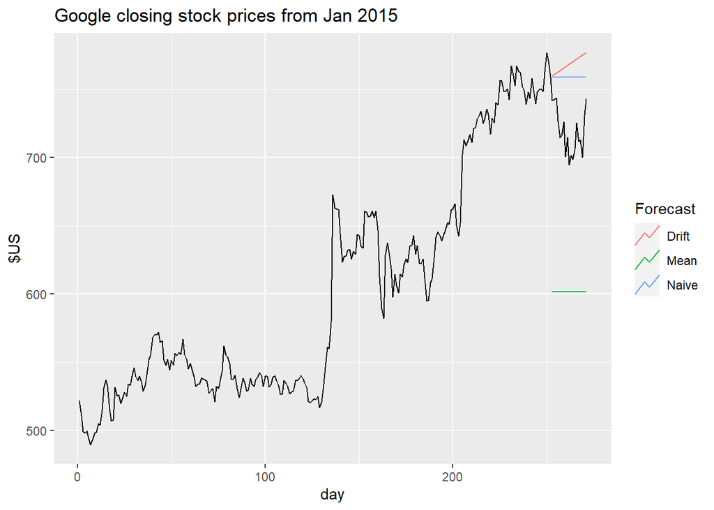

```r
google_fc %>%
    autoplot(bind_rows(google_2015, google_jan_2016),
             level = NULL) +
    labs(y = "$US",
         title = "Google closing stock prices from Jan 2015") +
    guides(colour = guide_legend(title = "Forecast"))
```

```r
accuracy(google_fc, google_stock)
```

```
## # A tibble: 3 x 11
##   .model Symbol .type    ME  RMSE   MAE   MPE  MAPE  MASE RMSSE  ACF1
##   <chr>  <chr>  <chr> <dbl> <dbl> <dbl> <dbl> <dbl> <dbl> <dbl> <dbl>
## 1 Drift  GOOG   Test  -49.8  53.1  49.8 -6.99  6.99  6.99  4.74 0.604
## 2 Mean   GOOG   Test  117.  118.  117.  16.2  16.2  16.4  10.5  0.496
## 3 Naive  GOOG   Test  -40.4  43.4  40.4 -5.67  5.67  5.67  3.88 0.496
```

naive method가 가장 좋은 결과를 보여준다는 것을 확인할 수 있다.